# Striped Bass: Tag Returns from Sub-Legal at Tagging

```r
library(dplyr)
library(ggplot2)
```

```r
# section: loads source files needed for analytics herein
source("source/methods_len_freq.R")
```

```r
# section: loads all necessary data with some subsetting & re-formatting
# from mark-recaptured database (see ImportTaggingData.R)
StriperAll <- readRDS(file = "data/tagging/StriperAll.rds")
AnglerReturns <- readRDS(file = "data/tagging/SBAnglerReturns.rds")
# for ease of analytics
AnglerReturns$RelYear <- format(as.Date(AnglerReturns[["RelDate"]]), format = "%Y")
# for analytics
Tagged2010Pres <- subset(
  StriperAll,
  # subset = RelYear > 2009 & Method %in% "FT"
  subset = RelYear > 2009
)
# for ease of analytics & plotting
Tagged2010Pres$FLCat <- NA_character_
Tagged2010Pres$FLCat[Tagged2010Pres[["FL"]] >= 42] <- "leg"
Tagged2010Pres$FLCat[Tagged2010Pres[["FL"]] < 42] <- "sub"
# want only tag returns from 2010- (when we began tagging sub-legal sized fish)
Returns2010Pres <- subset(
  AnglerReturns,
  subset = RelYear > 2009
  # subset = as.Date(RelDate) > "2009-12-31"
)
# some anglers report length in metrics (this is the conversion to standard for
# consistency with most angler reporting)
bool_metric <- Returns2010Pres[["IsMetric"]] == 1
Returns2010Pres[["RecFLIn"]][bool_metric] <-
  Returns2010Pres[["RecFLIn"]][bool_metric] / 2.54
# to show record of when gill netting - not used
# Tagged2010Pres[Tagged2010Pres[["Method"]] %in% "GN",]
```

## Introduction

In 2010, we began tagging sub-legal sized Striped Bass (i.e., < 42 cm fork length[FL]). Herein, we summarize sub-legal tagging (release) data and return (i.e., angler tag return) data to learn some about catch & release and learn more about this demographic of Striped Bass.

## Catch

Below, we show all Striped Bass caught and measured, less recaptures (i.e., within season and previous seasons). `Count` and `Prop` fields include only measured fish. (`Subs` < 42 cm FL; `Legs` ≥ 42 cm FL)

*Note*: 2018 data are incomplete (i.e., data entry ongoing) and will certainly change

*Note*: data are mostly from fyke trap tagging (in Knights Landing). Since 2010, we’ve tagged only one day using gill nets (2011-Apr-19, where we caught 17 Striped Bass, of which we tagged 16).

*Note*: in 2014 we did not tag Striped Bass

```r
all_summary <- Tagged2010Pres %>%
  filter(TagAction != 2) %>%
  group_by(RelYear) %>%
  summarise(
    AllCaught = sum(Count),
    AllMeas = sum(!is.na(FL)),
    CountSubs = sum(FL < 42, na.rm = TRUE),
    PropSubs = mean(FL < 42, na.rm = TRUE),
    CountLegs = sum(FL >= 42, na.rm = TRUE),
    PropLegs = mean(FL >= 42, na.rm = TRUE)
  )
as.data.frame(all_summary)
```

```
  RelYear AllCaught AllMeas CountSubs   PropSubs CountLegs  PropLegs
1    2010      1823    1820       396 0.21758242      1424 0.7824176
2    2011      5708    5685      2035 0.35795954      3650 0.6420405
3    2012      6642    6624       968 0.14613527      5656 0.8538647
4    2013      2684    2616       187 0.07148318      2429 0.9285168
5    2015       478     473        94 0.19873150       379 0.8012685
6    2016      4191    3694      1497 0.40525176      2197 0.5947482
7    2017      5519    5400      2375 0.43981481      3025 0.5601852
8    2018      2019    2014       643 0.31926514      1371 0.6807349
```

Here we present length-frequency distributions by year. Number represents the number of sub-legal Striped Bass caught and measured.

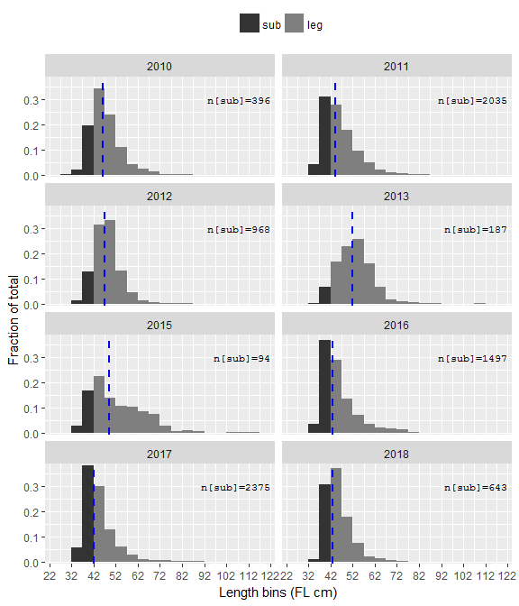

```r
# with(data = Tagged2010Pres, expr = {
#   tapply(FL, INDEX = RelYear, FUN = function(x) sum(x == 0, na.rm = TRUE))
#   # tapply(FL, INDEX = RelYear, FUN = function(x) sum(x < 32, na.rm = TRUE))
# })
# generate len-freq list for graphic display
lf <- GetLenFreq(
  Tagged2010Pres,
  colX = FL,
  by = "RelYear",
  seqBy = 5,
  subset = FL != 0
)
# create lf-dist figure
plot(
  lf,
  lens = FL,
  fillBar = FLCat,
  type = "POT",
  addMed = TRUE
) +
  facet_wrap(facets = ~RelYear, ncol = 2) +
  scale_fill_manual("", values = c(sub = "grey20", leg = "grey50")) +
  theme(legend.position = "top") +
  guides(fill = guide_legend(reverse = TRUE)) +
  xlab("Length bins (FL cm)") +
  geom_text(
    mapping = aes(label = paste0("n[sub]","=", CountSubs)),
    data = all_summary,
    hjust = 1,
    family = "mono",
    x = 122,
    y = 0.3,
    size = 3, parse = F
  )
```

## Tagged Fish

For only fish that were tagged (where field `TagAction` = 1), below are the count & proportions of sublegals (based on what was measured) along with some descriptive stats.

```r
# count for tagged fish is always 1 so length(TagNum) or sum(Count) will work
tagged <- Tagged2010Pres %>%
  filter(TagAction == 1) %>%
  # group_by(RelYear, TagAction) %>%
  group_by(RelYear) %>%
  summarise(
    # AllTagged = length(TagNum[!is.na(FL)]),
    AllTagged = length(TagNum),
    CountSubs = sum(FL < 42, na.rm = TRUE),
    PropSubs = mean(FL < 42, na.rm = TRUE),
    MinSubLen = min(FL[FL < 42], na.rm = TRUE),
    MaxSubLen = max(FL[FL < 42], na.rm = TRUE),
    AvgSubLen = mean(FL[FL < 42], na.rm = TRUE),
    SdSubLen = sd(FL[FL < 42], na.rm = TRUE)
  )
as.data.frame(tagged)
```

```
  RelYear AllTagged CountSubs   PropSubs MinSubLen MaxSubLen AvgSubLen SdSubLen
1    2010      1823       396 0.21758242        31        41  39.19697 1.838158
2    2011      4597      1588 0.34596950        32        41  38.80982 1.827220
3    2012      3913       563 0.14391616        30        41  38.95204 1.762452
4    2013      2634       187 0.07148318        34        41  39.48663 1.471442
5    2015       470        91 0.19402985        35        41  38.74725 1.859471
6    2016      1904       746 0.39242504        32        41  38.95442 1.827622
7    2017      2913      1361 0.46914857        31        41  38.52461 1.876210
8    2018      2019       643 0.31926514        31        41  39.45412 1.473228
```

## Tag Returns

Note: As data entry for 2018 is currently ongoing, we have not yet processed 2018 tag returns. But to date, we have received 10 returns from 2018 tagged fish.

```r
# Tagged2010Pres[Tagged2010Pres[["Method"]] %in% "GN",]
# sort(Tagged2010Pres[Tagged2010Pres[["Method"]] %in% "GN", "FL"])
# table(Returns2010Pres[["RelLoc"]], useNA = "ifany")
# FIO, uncomment as needed *********************************
# range(as.Date(Returns2010Pres[["RelDate"]]))
# range(Returns2010Pres[["RetYear"]], na.rm = TRUE)
# table(Returns2010Pres[["RelFL"]] < 42, useNA = "ifany")
# **********************************************************
# converting to factors for ease of analytics & plotting *************
Returns2010Pres$RelVal <- factor(
  Returns2010Pres[["RelVal"]],
  levels = c("NR", "20", "50", "100")
)
Returns2010Pres$RetYear <- factor(
  Returns2010Pres[["RetYear"]],
  levels = 1:6,
  # labels = c("1st", "2nd", "3rd", "4th", "5th", "6th")
  # labels = c("Frst", "Scnd", "Thrd", "Frth", "Ffth", "Sxth")
  labels = c("First", "Second", rep("Third+", times = 4))
)
# sets any NAs as unknown too
Returns2010Pres$Fate <- factor(
  Returns2010Pres[["Fate"]],
  levels = c("K", "R", "U", NA),
  labels = c("K", "R", "U", "U"),
  exclude = NULL
)
# ********************************************************************
# create a summary of returns (lists to be "unlisted" below)
return_summary <- Returns2010Pres %>%
  group_by(Year = format(RelDate, format = "%Y")) %>%
  filter(RelFL < 42) %>%
  summarise(
    CountTags = length(TagNum),
    FLRange = list(range(RelFL, na.rm = TRUE)),
    DALRange = list(range(DAL, na.rm = TRUE)),
    CountRelVal = list(table(RelVal, useNA = "ifany")),
    CountRelSex = list(table(RelSex, useNA = "ifany")),
    CountFate = list(table(Fate, useNA = "ifany")),
    CountRetYear = list(table(RetYear, useNA = "ifany")),
    Locations = list(table(RelLoc, RecLoc, useNA = "ifany"))
  )
# FIO **********************************
# return_summary[["DALRange"]]
# return_summary[["Locations"]]
# return_summary[["CountRelVal"]]
# return_summary[["CountRetYear"]]
# return_summary[["CountRelSex"]]
# return_summary[["CountFate"]]
# **************************************
```

Angler tag returns (of Striped Bass < 42 cm FL at tagging) for each release year (`Year`) by return year (`First`: caught within 365 days of tagging date; `Second`: caught between 365 and 730 days of tagging date; `Third+`: everything else beyond 730 days)

```r
return_year <- data.frame(
  Year = return_summary[["Year"]],
  do.call(what = rbind, args = return_summary[["CountRetYear"]]),
  stringsAsFactors = FALSE
)
colnames(return_year) <- c("Year", "First", "Second", "Third+")
return_year
```

```
  Year First Second Third+
1 2010     2      1      1
2 2011    22     10      2
3 2012     7      1      1
4 2013     4      1      0
5 2015     1      0      0
6 2016     6      8      0
7 2017    29      3      0
```

Angler tag returns (of Striped Bass < 42 cm FL at tagging) for each release year (`Year`) by fate (`K`: kept; `R`: released; `U`: unknown, angler did not supply info)

```r
data.frame(
  Year = return_summary[["Year"]],
  do.call(what = rbind, args = return_summary[["CountFate"]]),
  stringsAsFactors = FALSE
)
```

```
  Year  K  R  U
1 2010  1  0  3
2 2011 10 13 11
3 2012  3  3  3
4 2013  1  3  1
5 2015  0  1  0
6 2016  5  7  2
7 2017 17 11  4
```

```r
# section: subsets Returns2010Pres for ease of analytics & calculates how many
# fish per release year do not have an angler-reported length
subleg_returns <- subset(Returns2010Pres, subset = RelFL < 42)
bool_rec_len_na <- is.na(subleg_returns[["RecFLIn"]])
# sum(bool_rec_len_na)
# count by bool_rec_len_na for each release year
with(data = subleg_returns, expr = {

  yr <- format(as.Date(RelDate), format = "%Y")

  table(Year = yr, ReturnLengthNA = bool_rec_len_na)

})
```

```
      ReturnLengthNA
Year   FALSE TRUE
  2010     1    3
  2011    27    7
  2012     9    0
  2013     3    2
  2015     0    1
  2016    13    1
  2017    28    4
```

Figure shows angler reported length (inches) ~ fish length at tagged. Fish where no length reported by angler are not included in the figure below (see `TRUE` field in table above, 18 in total).

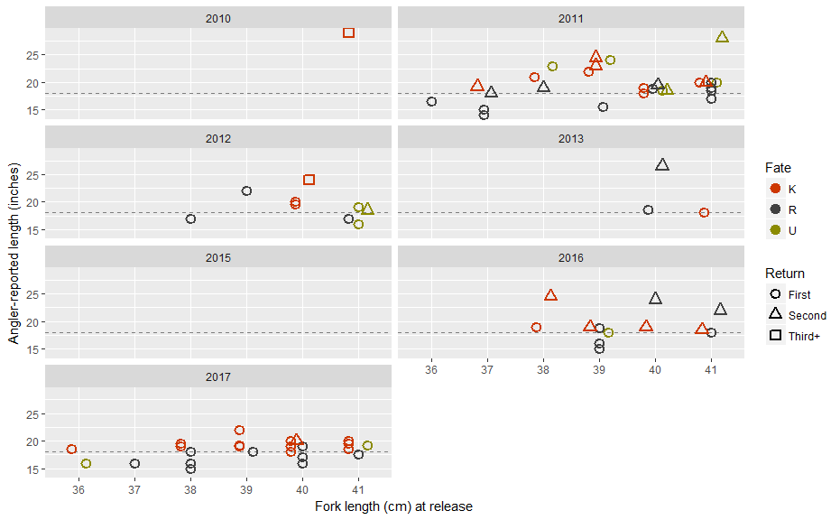

```r
# section:
# with(data = subset(Returns2010Pres, subset = RelFL < 42), expr = {
#
#   # table(RelFL, RecFLIn, Fate, useNA = "ifany")
#   as.data.frame(table(RelFL, RecFLIn, Fate, useNA = "ifany"))
#
# })
# for a bit of offsetting on x-axis
pd <- position_dodge(width = 0.5)
ggplot(data = subleg_returns, mapping = aes(x = factor(RelFL), y = RecFLIn)) +
  geom_hline(
    mapping = aes(yintercept = 18),
    colour = "grey20",
    linetype = 2,
    alpha = 3/5
  ) +
  geom_point(
    mapping = aes(colour = Fate, shape = RetYear),
    position = pd,
    size = 2.75,
    # alpha = 4/5,
    stroke = 1.5
  ) +
  facet_wrap(facets = ~ format(RelDate, "%Y"), ncol = 2) +
  scale_color_manual(
    values = c(K = "orangered3", R = "grey25", U = "yellow4")
  ) +
  scale_shape_manual(
    "Return",
    values = c(First = 1, Second = 2, `Third+` = 0)
  ) +
  labs(
    x = "Fork length (cm) at release",
    y = "Angler-reported length (inches)"
  )
```

## Analytics

Here, we show some “quick-n-dirty” analyes using angler tag returns (returns) and CDFW tag recaptures (recaptures). Again, we’ve constrained the size limit to sub-legal (i.e., fork length < 42 cm) **at** tagging.

We estimate survival rate, abundance, and catch & release rate according to the sections below. The table below shows (by release year, `RelYear`) count of returns, recaptures, and CDFW tag releases. Metadata (i.e., field descriptions) are provided below the table.

```r
years <- 2010:2018
rel_ret_count <- GetRelRetCount(
  mark = Tagged2010Pres,
  recap = Returns2010Pres,
  years = years
)
rel_ret_count$RR <- vapply(years, FUN = CountRecaps, FUN.VALUE = numeric(1L))
rel_ret_count
```

```
  RelYear   M1   C1 R11k R11r R11u   M2 R12 R22 RR
1    2010  396  396   NA   NA    2 1588   1  22  0
2    2011 1588 2035    5   10    7  563  10   7  0
3    2012  563  968    2    3    2  187   1   4  2
4    2013  187  187    1    2    1   NA   1  NA  1
5    2014   NA   NA   NA   NA   NA   91  NA   1  0
6    2015   91   94   NA    1   NA  746  NA   6  0
7    2016  746 1497    1    4    1 1361   8  29  3
8    2017 1361 2375   16   10    3  643   3  NA 14
9    2018  643  643   NA   NA   NA   NA  NA  NA  0
```

Metadata provided for reference.

```r
attr(rel_ret_count$RR, which = "metadata") <- "CDFW within-season recaptures"
metadata <- as.data.frame(
  do.call(
    what = rbind,
    args = Map(function(x) attr(x, which = "metadata"), rel_ret_count)
  )
)
colnames(metadata) <- ""
metadata
```

```
RelYear                                                   release or tagging year
M1                                                    fish tagged in release year
C1      fish caught in release year, includes tagged fish (M1) but not recaptures
R11k     first-year tag returns from release year (fate: kept, released, unknown)
R11r                                                                     see R11k
R11u                                                                     see R11k
M2                                                fish tagged in release year + 1
R12                                     second-year tag returns from release year
R22                                  first-year tag returns from release year + 1
RR                                                  CDFW within-season recaptures
```

#### Survival

$\hat{S}=\frac{R12\times M2}{M1\times R22}$

```r
# survival
s_hat <- with(data = rel_ret_count, expr = {
  (R12 * M2) / (M1 * R22)
})
data.frame(
  RelYear = rel_ret_count[["RelYear"]],
  SurvEst = s_hat
)
```

```
  RelYear   SurvEst
1    2010 0.1822773
2    2011 0.5064772
3    2012 0.0830373
4    2013        NA
5    2014        NA
6    2015        NA
7    2016 0.5032819
8    2017        NA
9    2018        NA
```

#### Abundance

$\hat{N}=\frac{M1\times(C1+1)}{RR+1}$

```r
data.frame(
  RelYear = rel_ret_count[["RelYear"]],
  # AbundEst = round(abund, digits = 0),
  AbundEst = format(abund, digits = 0, big.mark = ",", scientific = FALSE)
)
```

```
  RelYear  AbundEst
1    2010   157,212
2    2011 3,233,168
3    2012   181,849
4    2013    17,578
5    2014        NA
6    2015     8,645
7    2016   279,377
8    2017   215,582
9    2018   414,092
```

#### Catch & Release

We calculate catch & release as the proportion (`p.R11r`) of tag returns reported as released (`R11r`) from the total tag returns (see `R11All` in table below). Total tag returns includes those where fate was not reported (`u`). `p.R11r` varies between ~35% and 67%.

```r
# for selecting specfic columns within rel_ret_count
cols_R11 <- c("R11k", "R11r", "R11u")
data.frame(
  rel_ret_count[, c("RelYear", cols_R11)],
  R11All = rowSums(rel_ret_count[, cols_R11], na.rm = TRUE),
  p = round(
    prop.table(as.matrix(rel_ret_count[, cols_R11]), margin = 1),
    digits = 3
  )
)
```

```
  RelYear R11k R11r R11u R11All p.R11k p.R11r p.R11u
1    2010   NA   NA    2      2     NA     NA     NA
2    2011    5   10    7     22  0.227  0.455  0.318
3    2012    2    3    2      7  0.286  0.429  0.286
4    2013    1    2    1      4  0.250  0.500  0.250
5    2014   NA   NA   NA      0     NA     NA     NA
6    2015   NA    1   NA      1     NA     NA     NA
7    2016    1    4    1      6  0.167  0.667  0.167
8    2017   16   10    3     29  0.552  0.345  0.103
9    2018   NA   NA   NA      0     NA     NA     NA
```

CDFW, SportFish Unit  
ran: 2018-06-15 11:52:19